# Figures for paper

Rachael ‘Rocky’ Aikens, Voight Lab

August 3, 2017

# Table 1

To make this table, we need the following **functions** and *datasets*:

- *3mer count dataframes for all ancestral continental groups, in 1,000 genomes and SGDP*
- **Fourway.chi** Tests for heterogeneity among any four count dataframes
- **ordered.p** performs ordered p value correction
- **Pairwise.chi** Tests for heterogeneity between any two count dataframes

14 most significant 3mers using ordered p value correction

| Context | AFR relative rate | EUR relative rate | SAS relative rate | EAS relative rate | p (1,000 genomes) | p (SGDP) |
| --- | --- | --- | --- | --- | --- | --- |
| TCC->T | 1 | 1.56 | 1.2 | 1 | 0.000000e+00 | 0.000000e+00 |
| ACC->T | 1 | 1.2 | 1.07 | 0.93 | 3.000000e-308 | 2.308971e-161 |
| TCT->T | 1 | 1.17 | 1.06 | 0.98 | 2.868119e-196 | 0.000000e+00 |
| GAT->T | 1 | 1.06 | 1.13 | 1.21 | 5.361344e-111 | 1.446486e-23 |
| ACC->A | 1 | 1.04 | 1.1 | 1.15 | 1.248600e-98 | 4.690665e-17 |
| CCC->T | 1 | 1.06 | 1.03 | 0.95 | 2.154370e-69 | 6.223829e-68 |
| ACA->T | 1 | 0.95 | 0.97 | 0.93 | 2.904922e-60 | 2.622420e-30 |
| TCA->T | 1 | 1.06 | 1.03 | 0.97 | 9.743309e-52 | 1.663031e-13 |
| ACT->T | 1 | 1.02 | 1 | 0.94 | 3.142140e-51 | 1.194046e-45 |
| GAC->T | 1 | 1.02 | 1.09 | 1.2 | 6.496890e-40 | 5.573266e-10 |
| GCC->T | 1 | 1.06 | 1.03 | 1.02 | 1.095624e-37 | 3.297963e-14 |
| CAC->G | 1 | 0.93 | 0.92 | 0.96 | 7.055889e-33 | 4.470856e-16 |
| CCA->T | 1 | 0.93 | 0.97 | 0.95 | 3.035663e-27 | 1.507226e-31 |
| GCC->A | 1 | 1.02 | 1.07 | 1.08 | 8.042908e-25 | 2.566652e-05 |

Certain table entries are bold if they are significantly enriched in Africa. The code below calculates which threemers are significantly different (p<1e-5) between AFR and EUR in table 1.

[output not shown]

|  | Context | Counts1 | Counts2 | p |
| --- | --- | --- | --- | --- |
| 16 | ACC->A | 76646 | 23819 | 0.0e+00 |
| 18 | ACC->T | 135088 | 40890 | 0.0e+00 |
| 25 | TCT->T | 144254 | 43187 | 0.0e+00 |
| 37 | GAT->T | 47152 | 15054 | 0.0e+00 |
| 47 | CAC->G | 93424 | 24129 | 0.0e+00 |
| 54 | CCA->T | 150198 | 40877 | 5.2e-06 |
| 57 | CCC->T | 133143 | 38511 | 0.0e+00 |
| 78 | GAC->T | 21353 | 6569 | 0.0e+00 |
| 82 | GCC->A | 50331 | 15163 | 0.0e+00 |
| 84 | GCC->T | 123557 | 35857 | 0.0e+00 |
| 85 | TCC->T | 129676 | 43951 | 0.0e+00 |
| 96 | TCA->T | 134514 | 38964 | 0.0e+00 |

|  | Context | Counts1 | Counts2 | p |
| --- | --- | --- | --- | --- |
| 15 | ACA->T | 227803 | 58806 | 0.0e+00 |
| 16 | ACC->A | 76646 | 24481 | 0.0e+00 |
| 18 | ACC->T | 135088 | 35002 | 0.0e+00 |
| 24 | ACT->T | 157475 | 41237 | 0.0e+00 |
| 37 | GAT->T | 47152 | 15883 | 0.0e+00 |
| 47 | CAC->G | 93424 | 24869 | 0.0e+00 |
| 54 | CCA->T | 150198 | 39701 | 0.0e+00 |
| 57 | CCC->T | 133143 | 35129 | 0.0e+00 |
| 78 | GAC->T | 21353 | 7135 | 0.0e+00 |
| 82 | GCC->A | 50331 | 15160 | 0.0e+00 |
| 84 | GCC->T | 123557 | 35281 | 1.7e-06 |

# Figure 1

## A: heatmap of all 3mer mutation types

To make this figure, we need the following **functions** and *datasets*:

- **norm/norm.byrow** need these to normalize the data before making a heatmap
- **make.heatmap** calls heatmap2 to make a heatmap. The function defined herein is slightly different from the one in the heatmaps_report workflow; there are some small modifications to format the dendrogram and plot area specifically for this figure.
- *3mer rate matrix* saved in ‘rate_profiles/rates_3mer.txt’

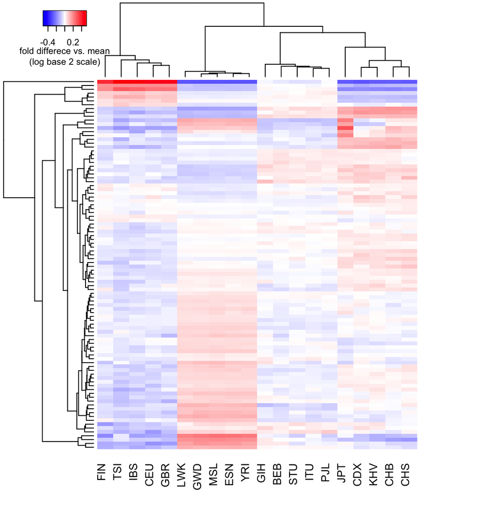

## BC: CI plots of polymorphism clusters

To make these panels, I need the following **functions** and *datasets*:

- **CI.plot.bygroup** Makes a plot of the rates of a group of mutations. Will bug out if the mutations are of the same context, although that’s not a problem for these figures.

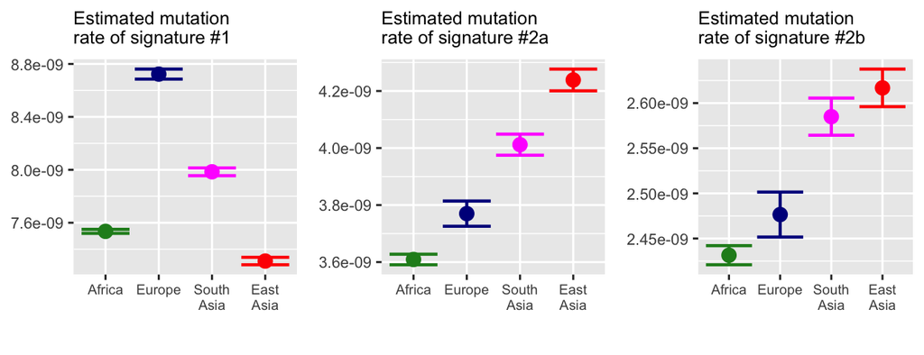

## D: CI plots for signal 3

This figure was harder to make, and we’ll probably revamp the way we do it. Once we’ve figured that out, I’ll add that code here. For now, this figure requires the following:

- **CI.plotsubpop.bygroup** same as CI.plot.bygroup, but works for more populations than just the ancestral continental groups.
- *3mer count dataframes for all ancestral continental groups (except EAS)*
- *3mer count dataframes for all EAS subpopulations*

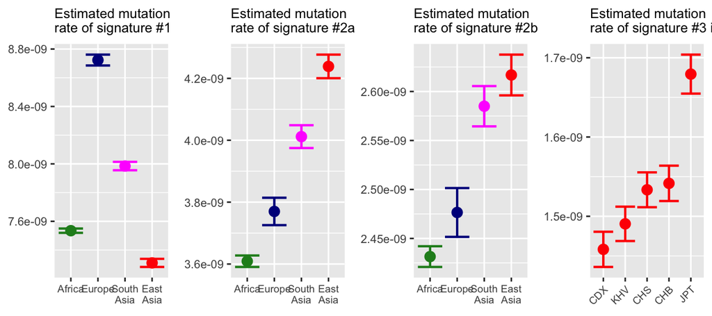

# Figure 2

## AB: scatter plot examples

To make these figures, I need

- **subrate.scplot** makes a scatterplot of all 7mers with a given 3mer subtype.
- *7mer count dataframes for JPT and CDX*
- *7mer count dataframes for East Asia and Europe*

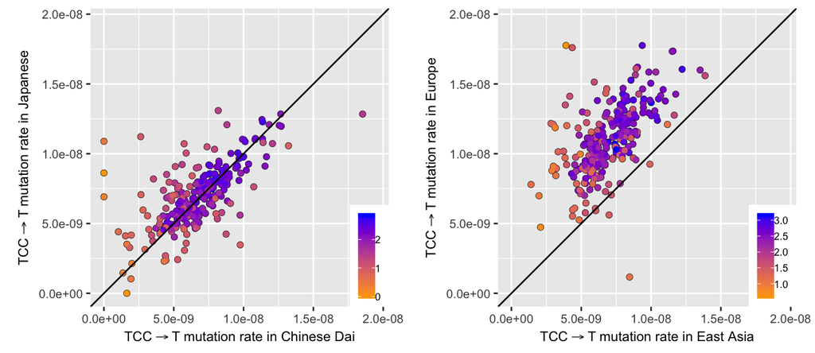

# Figure 3

## A: table of X enriched polymorphisms

We can obtain the first set of fdr-adjusted p values using a pairwise chi squared test between CDX and JPT 7mers whose 3mer subcontext is a part of signal 4.

| Context | Counts1 | Counts2 | p | fdr |
| --- | --- | --- | --- | --- |
| TTTATTT->T | 261 | 525 | 8.008067e-25 | 6.398446e-22 |
| CAAACCC->C | 22 | 109 | 3.137120e-15 | 1.253279e-12 |
| AGTACAG->C | 3 | 46 | 4.729572e-10 | 1.259643e-07 |
| TCAACAG->C | 7 | 37 | 4.494406e-06 | 8.977577e-04 |
| ATAACAG->C | 10 | 41 | 9.325240e-06 | 1.177996e-03 |
| ATGACAG->C | 9 | 39 | 1.032037e-05 | 1.177996e-03 |
| CCCACAG->C | 29 | 71 | 9.726639e-06 | 1.177996e-03 |
| ACCACCA->C | 12 | 37 | 2.571444e-04 | 2.568230e-02 |
| AAGACAG->C | 12 | 36 | 3.943034e-04 | 2.779293e-02 |
| AATACAG->C | 12 | 36 | 3.943034e-04 | 2.779293e-02 |
| ACAACAG->C | 6 | 26 | 3.970097e-04 | 2.779293e-02 |
| ATCACAG->C | 16 | 42 | 4.174157e-04 | 2.779293e-02 |
| GTGACAG->C | 4 | 22 | 4.663778e-04 | 2.866430e-02 |
| TTTATTA->T | 79 | 121 | 7.945720e-04 | 4.534736e-02 |

```
## [1] 5.282929
```

Next, we have to run a test for X enrichment, described in the paper.

| Context | Autosomes | X | Autosomal_sites | X_sites | alpha | p.0 | p.MLE | p | Expected |
| --- | --- | --- | --- | --- | --- | --- | --- | --- | --- |
| TTTATTT->T | 743 | 65 | 1444601 | 119969 | 0.7702833 | 3.961789e-04 | 5.418066e-04 | 9.214683e-03 | 47.529190 |
| AAGACAG->C | 50 | 4 | 298423 | 24142 | 0.7702833 | 1.290590e-04 | 1.656864e-04 | 3.786818e-01 | 3.115742 |
| AATACAG->C | 44 | 1 | 258885 | 21463 | 0.7702833 | 1.309171e-04 | 4.659181e-05 | 9.397984e-01 | 2.809873 |
| ACAACAG->C | 34 | 3 | 202230 | 17800 | 0.7702833 | 1.295042e-04 | 1.685393e-04 | 4.053381e-01 | 2.305175 |
| ACCACCA->C | 48 | 3 | 266068 | 19888 | 0.7702833 | 1.389630e-04 | 1.508447e-04 | 5.218604e-01 | 2.763695 |
| AGTACAG->C | 51 | 4 | 143524 | 10787 | 0.7702833 | 2.737134e-04 | 3.708167e-04 | 3.421365e-01 | 2.952547 |
| ATAACAG->C | 50 | 4 | 185557 | 15802 | 0.7702833 | 2.075597e-04 | 2.531325e-04 | 4.152149e-01 | 3.279859 |
| ATCACAG->C | 57 | 4 | 216095 | 15185 | 0.7702833 | 2.031798e-04 | 2.634178e-04 | 3.718700e-01 | 3.085286 |
| ATGACAG->C | 39 | 4 | 196359 | 15670 | 0.7702833 | 1.529904e-04 | 2.552648e-04 | 2.207159e-01 | 2.397360 |
| CAAACCC->C | 101 | 27 | 136995 | 10993 | 0.7702833 | 5.678938e-04 | 2.456108e-03 | 6.718695e-10 | 6.242857 |
| CCCACAG->C | 80 | 25 | 206875 | 15550 | 0.7702833 | 2.978739e-04 | 1.607717e-03 | 3.316706e-11 | 4.631939 |
| GTGACAG->C | 24 | 1 | 228147 | 15040 | 0.7702833 | 8.103021e-05 | 6.648936e-05 | 7.043987e-01 | 1.218694 |
| TCAACAG->C | 35 | 7 | 165015 | 13875 | 0.7702833 | 1.633786e-04 | 5.045045e-04 | 8.691211e-03 | 2.266878 |
| TTTATTA->T | 209 | 15 | 577465 | 47331 | 0.7702833 | 2.787861e-04 | 3.169170e-04 | 3.449266e-01 | 13.195224 |

## BC

These two panels use datasets and functions:

- **subrate.scplot**
- **CI.plot.subpop.bygroup**
- *7mer count dataframes for all EAS subpops*

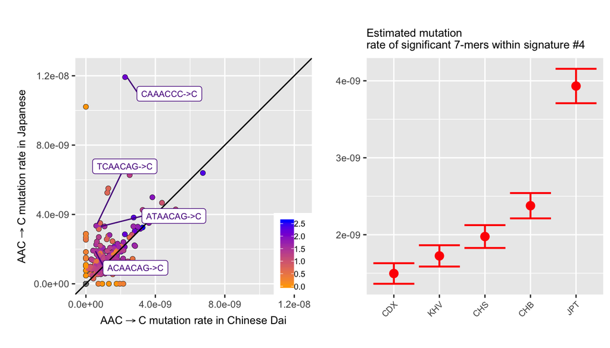

# 5mer and 7mer chi squared tests

## 5mer

1535 out of 1536 5mer polymorphism classes appear > 5 times in all continental groups. The only polymorphism with insufficient data for chi squared testing is:

| Context | X3mer | X1mer | AFR.Count | EUR.Count | EAS.Count | SAS.Count | p |
| --- | --- | --- | --- | --- | --- | --- | --- |
| CGACG->C | GAC->C | A->C | 22 | 3 | 9 | 6 | NA |

Letting the alpha value be 0.05/1535, we have the following number of significant results:

```
## [1] 156
```

This many are expansions signature 1 polymorphisms

```
## [1] 57
```

This many are expansions of 3mers in signatures 1 and 2, or table 1 reported in this paper.

```
## [1] 107
```

This leaves this many new results

```
## [1] 49
```

## 7mer

20665 out of 24576 7mer polymorphism classes appear > 5 times in all continental groups.

```
## [1] 20665     9
```

Letting the alpha value be 0.05/20665, we have the following number of significant results:

```
## [1] 142
```

This many are expansions signature 1 polymorphisms

```
## [1] 111
```

This many are expansions of 3mers in signature 2 reported in this paper.

```
## [1] 6
```

This leaves this many new results

```
## [1] 25
```

5 most significant new 7mers using ordered p value correction

| Context | AFR relative rate | EUR relative rate | SAS relative rate | EAS relative rate | p |
| --- | --- | --- | --- | --- | --- |
| CAAACCC->C | 1 | 0.9421718 | 0.3354900 | 3.6172576 | 2.967514e-39 |
| TTTATTT->T | 1 | 0.8383999 | 0.6070058 | 1.0371639 | 2.361309e-25 |
| TTTAAAA->T | 1 | 0.8879930 | 0.8413135 | 0.8782003 | 1.503464e-21 |
| ATTAAAA->T | 1 | 0.7149999 | 0.7603730 | 0.8152057 | 2.253947e-21 |
| AAACAAA->A | 1 | 0.7804857 | 0.6603116 | 0.8845471 | 2.357010e-21 |

The code below checks for significant pairwise differences with AFR using p-ordered correction. This determines which reates are boldface in Figure4A:

|  | Context | Counts1 | Counts2 | p |
| --- | --- | --- | --- | --- |
| 10173 | ATTAAAA->T | 3773 | 496 | 0 |

|  | Context | Counts1 | Counts2 | p |
| --- | --- | --- | --- | --- |
| 193 | AAACAAA->A | 3108 | 578 | 0 |
| 574 | TTTATTT->T | 2796 | 478 | 0 |
| 10173 | ATTAAAA->T | 3773 | 808 | 0 |
| 24573 | TTTAAAA->T | 12011 | 2846 | 0 |

|  | Context | Counts1 | Counts2 | p |
| --- | --- | --- | --- | --- |
| 10173 | ATTAAAA->T | 3773 | 857 | 1e-07 |
| 10801 | CAAACCC->C | 127 | 128 | 0e+00 |
| 24573 | TTTAAAA->T | 12011 | 2939 | 0e+00 |

# Figure 4

## AB

- **subrate.scplot**
- *7mer count dataframes for all nonadmixed continental populations*

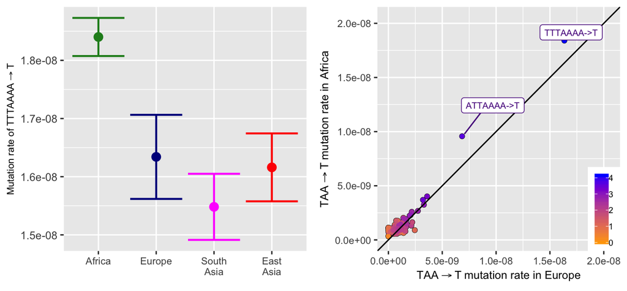